# Coursera_DS-Regression_Quiz1

Frank Fichtenmueller

26 October 2016

#### Question 1

```r
x <- c(0.18, -1.54, 0.42, 0.95)
w <- c(2, 1, 3, 1)

#Using the manual method we calculate mu
mu <- sum(w*x)/sum(w)
round(mu,4)
```

```
## [1] 0.1471
```

```r
#Using the built in lm function
lm(x ~ 1, weights=w)$coefficients
```

```
## (Intercept)
##   0.1471429
```

#### Question 2

Given x and y, calculate the linear regression model to approximate the Data

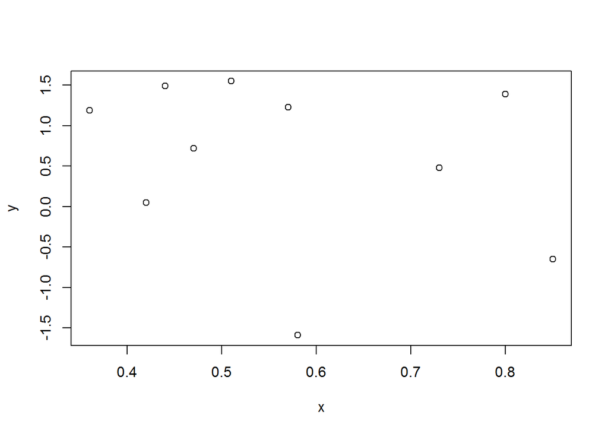

```r
x <- c(0.8, 0.47, 0.51, 0.73, 0.36, 0.58, 0.57, 0.85, 0.44, 0.42)
y <- c(1.39, 0.72, 1.55, 0.48, 1.19, -1.59, 1.23, -0.65, 1.49, 0.05)
plot(x,y)
```

```r
lm(y~ 0 + x)$coefficients[2]
```

```
## <NA>
##   NA
```

#### Question 3

fit the regression model to the mtcars datset with mpg as the outcome and weight as the predictor

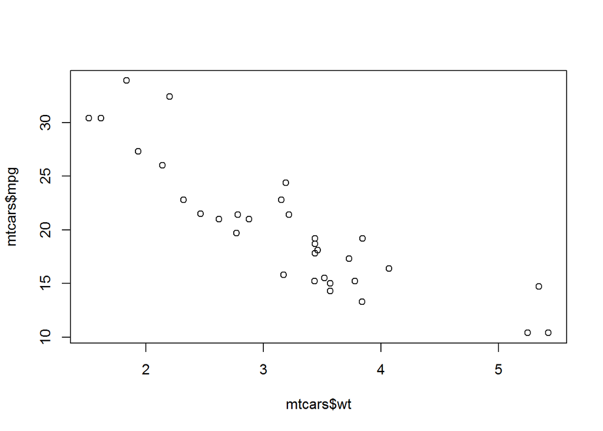

```r
data(mtcars)
plot(mtcars$wt, mtcars$mpg)
```

```r
lm(mtcars$mpg ~ mtcars$wt)$coefficients[2]
```

```
## mtcars$wt
## -5.344472
```

#### Question 4

Consider data with an outcome (Y) and a predictor (X). The standard deviation of the predictor is one half that of the outcome. The correlation between the two variables is .5. What value would the slope coefficient for the regression model with Y as the outcome and X as the predictor?

$$\begin{align} \hat \beta_1 &= Cor(X,Y) \frac{Sd(Y)}{Sd(X)} \ &= (0.5) \frac{Sd(Y)}{0.5Sd(Y)} \ &= 1 \end{align}$$

#### Question 5

Students were given two hard tests and scores were normalized to have empirical mean 0 and variance 1. The correlation between the scores on the two tests was 0.4. What would be the expected score on Quiz 2 for a student who had a normalized score of 1.5 on Quiz 1?

```r
# t2 = t1 * 0.4
    t2 <- 1.5 * 0.4
    t2
```

```
## [1] 0.6
```

#### Question 6

What is the value of the first measurement if x were normalized (to have mean 0 and variance 1)?

```r
x <- c(8.58, 10.46, 9.01, 9.64, 8.86)
x <- (x-mean(x))/sd(x)
x[1]
```

```
## [1] -0.9718658
```

#### Question 7

Consider the following data set (used above as well).

```r
x <- c(0.8, 0.47, 0.51, 0.73, 0.36, 0.58, 0.57, 0.85, 0.44, 0.42)
y <- c(1.39, 0.72, 1.55, 0.48, 1.19, -1.59, 1.23, -0.65, 1.49, 0.05)
```

What is the intercept for fitting the model with x as the predictor and y as the outcome?

```r
names(lm(y ~ x))[1]
```

```
## [1] "coefficients"
```

```r
lm(y~x)$coefficients[1]
```

```
## (Intercept)
##    1.567461
```

#### Question 8

You know that both the predictor and response have mean 0. What can be said about the intercept when you fit a linear regression?

- It must be exactly one.
- It must be identically 0. <–
- Nothing about the intercept can be said from the information given.
- It is undefined as you have to divide by zero.

#### Question 9

```r
rm(list = ls())
```

Consider the data given

```r
x <- c(0.8, 0.47, 0.51, 0.73, 0.36, 0.58, 0.57, 0.85, 0.44, 0.42)
```

```r
mean(x)
```

```
## [1] 0.573
```

#### Question 10

Consider taking the slope having fit Y as the outcome and X as the predictor, $\beta_1$ and the slope from fitting X as the outcome and Y as the predictor, $\gamma_1$, and dividing the two as $\beta_1/\gamma_1$. What is this ratio always equal to?

- Cor(Y,X)
- 1
- 2SD(Y)/SD(X)
- Var(Y)/Var(X) <–